# R Notebook

A real estate company in NYC is looking for properties to invest in. They spend a lot of time searching for profitable properties. They need help streamlining this process and making it more efficient.

I will find properties for them to invest in by: - looking into a dataset of past NYC property sales - finding out what makes a property profitable - finding out what makes a profitable property different than other properties

```r
library(dplyr)
library(tidyr)
library(ggplot2)
library(forcats)
```

```r
nyc_prop_sales <- read.csv("./projectApp/nyc-rolling-sales.csv")
```

I defined a ‘profitable property’ by: - a property that sold for lower than the average sale price of properties in the same neighborhood and of the same type (1bd apt, studio, house, etc). - a property that has an increasing property value and has a mortgage price that is less than the average rent price for that neighborhood and type.

Unfortunately, this dataset does not contain the right information to find the average rent price by neighborhood and property type.

For this project, I will focus on the properties with a below average sale price for their neighborhood and type.

1. Find the average and standard deviation of the sale price for each neighborhood and type and add them to the dataframe.

```r
# Change column names to be easier to use
names(nyc_prop_sales) = gsub("square_feet", "sqft", gsub("time_of_sale", "tos",gsub("\\.", "_", tolower(names(nyc_prop_sales)))))

# Change sale_price, gross_sqft and land_sqft to numbers and null values
nyc_prop_sales$sale_price = as.numeric(as.character(nyc_prop_sales$sale_price))
```

```
NAs introduced by coercion
```

```r
nyc_prop_sales$gross_sqft = as.numeric(as.character(nyc_prop_sales$gross_sqft))
```

```
NAs introduced by coercion
```

```r
nyc_prop_sales$land_sqft = as.numeric(as.character(nyc_prop_sales$land_sqft))
```

```
NAs introduced by coercion
```

```r
# Remove inherited properties and garage spots
nyc_prop_sales = nyc_prop_sales %>% filter(., sale_price > 100000, gross_sqft > 10)

# Change borough numbers to borough names
nyc_prop_sales = nyc_prop_sales %>%
  mutate(.,
         borough = ifelse( borough == 1, "Manhattan",
                     ifelse(borough == 2, "Bronx",
                      ifelse(borough == 3, "Brooklyn",
                        ifelse(borough == 4, "Queens", "Staten Island") ) ) ) )

nyc_prop_sales %>% arrange(., sale_price)
```

| x | borough | neighborhood | building_class_category | tax_class_at_present | block | lot | ease_ment | building_class_at_present | address | apartment_number | zip_code | residential_units | commercial_units | total_units | land_sqft | gross_sqft | year_built | tax_class_at_tos | building_class_at_tos | sale_price | sale_date |
| --- | --- | --- | --- | --- | --- | --- | --- | --- | --- | --- | --- | --- | --- | --- | --- | --- | --- | --- | --- | --- | --- |
| 3708 | Staten Island | MIDLAND BEACH | 01 ONE FAMILY DWELLINGS | 1 | 3689 | 57 | NA | A6 | 341 BEDFORD AVENUE |  | 10306 | 1 | 0 | 1 | 2000 | 588 | 1945 | 1 | A6 | 100700 | 2017-07-19 00:00:00 |
| 19816 | Brooklyn | PARK SLOPE SOUTH | 03 THREE FAMILY DWELLINGS | 1 | 1016 | 1 | NA | C0 | 461 4 AVENUE |  | 11215 | 3 | 0 | 3 | 2000 | 2781 | 1899 | 1 | C0 | 101000 | 2017-02-02 00:00:00 |
| 15236 | Queens | JAMAICA | 02 TWO FAMILY DWELLINGS | 1 | 10216 | 1 | NA | S2 | 176-06 JAMAICA AVENUE |  | 11432 | 2 | 1 | 3 | 14376 | 3225 | 2006 | 1 | S2 | 101365 | 2016-09-29 00:00:00 |
| 2533 | Bronx | MELROSE/CONCOURSE | 03 THREE FAMILY DWELLINGS | 1 | 2448 | 26 | NA | C0 | 1055 MORRIS AVENUE |  | 10456 | 3 | 0 | 3 | 2538 | 3972 | 1905 | 1 | C0 | 101500 | 2016-11-22 00:00:00 |
| 19950 | Queens | REGO PARK | 02 TWO FAMILY DWELLINGS | 1 | 3144 | 15 | NA | B3 | 85-65 67TH AVENUE |  | 11374 | 2 | 0 | 2 | 4092 | 2128 | 1940 | 1 | B3 | 102900 | 2017-07-10 00:00:00 |
| 24826 | Queens | ST. ALBANS | 01 ONE FAMILY DWELLINGS | 1 | 11070 | 112 | NA | A1 | 116-39 198TH STREET |  | 11412 | 1 | 0 | 1 | 2265 | 1395 | 1925 | 1 | A1 | 103000 | 2016-11-27 00:00:00 |
| 6536 | Staten Island | SOUTH BEACH | 01 ONE FAMILY DWELLINGS | 1 | 3122 | 167 | NA | A2 | 11 SUNNYMEADE VILLAGE |  | 10305 | 1 | 0 | 1 | 2542 | 560 | 1920 | 1 | A2 | 103000 | 2016-10-19 00:00:00 |
| 890 | Bronx | BRONXDALE | 01 ONE FAMILY DWELLINGS | 1 | 4638 | 13 | NA | A2 | 3318 HONE AVENUE |  | 10469 | 1 | 0 | 1 | 2500 | 837 | 1899 | 1 | A2 | 104000 | 2016-09-01 00:00:00 |
| 3679 | Queens | COLLEGE POINT | 01 ONE FAMILY DWELLINGS | 1 | 4254 | 81 | NA | A5 | 25-30 COLLEGE POINT BOULEV |  | 11354 | 1 | 0 | 1 | 1914 | 1318 | 1960 | 1 | A5 | 104000 | 2016-12-23 00:00:00 |
| 4517 | Staten Island | NEW DORP-HEIGHTS | 01 ONE FAMILY DWELLINGS | 1 | 949 | 326 | NA | A1 | 82 WALDEN AVENUE |  | 10306 | 1 | 0 | 1 | 5829 | 2266 | 1975 | 1 | A1 | 104500 | 2017-01-20 00:00:00 |

[output cut: 990 more lines]

```r
# Create table including the avg sale price and avg standard deviation for each group, defined by the neighborhood and building_class_at_tos.
# Also includes amount of property sales in these groups and keep only the top 100 groups based on amount of property sales. Anything with too few property sales can not be properly analyzed.
nyc_prop_sales_100 = nyc_prop_sales %>%
  drop_na(., sale_price, gross_sqft) %>%
group_by(., neighborhood, building_class_at_tos) %>%
summarise(., avg_sale_price = mean(sale_price),
             sd_sale_price = sd(sale_price),
             amount = n(),
             avg_residential_units = mean(residential_units),
             avg_commercial_units = mean(commercial_units),
             avg_total_units = mean(total_units),
             avg_land_sqft = round(mean(land_sqft)),
             avg_gross_sqft = round(mean(gross_sqft)),
             avg_year_built = round(mean(year_built))) %>%
arrange(., desc(amount)) %>%
head(100)
# Combine original table and new table to add the columns of amount of properties in group, avg sale price and avg standard deviation.
# Keeps only the top 100 groups based on amount of property sales.
nyc_prop_sales_w_avgs = inner_join(nyc_prop_sales, nyc_prop_sales_100, by = c("neighborhood", "building_class_at_tos")) %>% select(., -x, -block, -lot, -address, -apartment_number, -ease_ment)

nyc_prop_sales_w_avgs %>% arrange(., desc(amount))
```

| borough | neighborhood | building_class_category | tax_class_at_present | building_class_at_present | zip_code | residential_units | commercial_units | total_units | land_sqft | gross_sqft | year_built | tax_class_at_tos | building_class_at_tos | sale_price | sale_date | avg_sale_price | sd_sale_price | amount | avg_residential_units | avg_commercial_units | avg_total_units | avg_land_sqft | avg_gross_sqft | avg_year_built |
| --- | --- | --- | --- | --- | --- | --- | --- | --- | --- | --- | --- | --- | --- | --- | --- | --- | --- | --- | --- | --- | --- | --- | --- | --- |
| Queens | FLUSHING-NORTH | 01 ONE FAMILY DWELLINGS | 1 | A1 | 11357 | 1 | 0 | 1 | 2650 | 1346 | 1925 | 1 | A1 | 915000 | 2017-08-29 00:00:00 | 921816.4 | 248079.54 | 233 | 1 | 0 | 1 | 4162 | 1692 | 1933 |
| Queens | FLUSHING-NORTH | 01 ONE FAMILY DWELLINGS | 1 | A1 | 11357 | 1 | 0 | 1 | 4000 | 1176 | 1925 | 1 | A1 | 878000 | 2016-11-29 00:00:00 | 921816.4 | 248079.54 | 233 | 1 | 0 | 1 | 4162 | 1692 | 1933 |
| Queens | FLUSHING-NORTH | 01 ONE FAMILY DWELLINGS | 1 | A1 | 11357 | 1 | 0 | 1 | 5000 | 1292 | 1925 | 1 | A1 | 800000 | 2017-08-10 00:00:00 | 921816.4 | 248079.54 | 233 | 1 | 0 | 1 | 4162 | 1692 | 1933 |
| Queens | FLUSHING-NORTH | 01 ONE FAMILY DWELLINGS | 1 | A1 | 11354 | 1 | 0 | 1 | 4500 | 1254 | 1910 | 1 | A1 | 645000 | 2017-01-31 00:00:00 | 921816.4 | 248079.54 | 233 | 1 | 0 | 1 | 4162 | 1692 | 1933 |
| Queens | FLUSHING-NORTH | 01 ONE FAMILY DWELLINGS | 1 | A1 | 11354 | 1 | 0 | 1 | 7700 | 1936 | 1915 | 1 | A1 | 993000 | 2017-08-28 00:00:00 | 921816.4 | 248079.54 | 233 | 1 | 0 | 1 | 4162 | 1692 | 1933 |
| Queens | FLUSHING-NORTH | 01 ONE FAMILY DWELLINGS | 1 | A1 | 11354 | 1 | 0 | 1 | 7700 | 1936 | 1915 | 1 | A1 | 895000 | 2017-07-12 00:00:00 | 921816.4 | 248079.54 | 233 | 1 | 0 | 1 | 4162 | 1692 | 1933 |
| Queens | FLUSHING-NORTH | 01 ONE FAMILY DWELLINGS | 1 | A1 | 11354 | 1 | 0 | 1 | 3424 | 1056 | 1955 | 1 | A1 | 735000 | 2016-12-01 00:00:00 | 921816.4 | 248079.54 | 233 | 1 | 0 | 1 | 4162 | 1692 | 1933 |
| Queens | FLUSHING-NORTH | 01 ONE FAMILY DWELLINGS | 1 | A1 | 11354 | 1 | 0 | 1 | 3600 | 1406 | 1960 | 1 | A1 | 828000 | 2017-04-13 00:00:00 | 921816.4 | 248079.54 | 233 | 1 | 0 | 1 | 4162 | 1692 | 1933 |
| Queens | FLUSHING-NORTH | 01 ONE FAMILY DWELLINGS | 1 | A1 | 11354 | 1 | 0 | 1 | 2800 | 1406 | 1960 | 1 | A1 | 915000 | 2017-02-15 00:00:00 | 921816.4 | 248079.54 | 233 | 1 | 0 | 1 | 4162 | 1692 | 1933 |
| Queens | FLUSHING-NORTH | 01 ONE FAMILY DWELLINGS | 1 | A1 | 11354 | 1 | 0 | 1 | 6789 | 2971 | 1930 | 1 | A1 | 1285000 | 2016-10-12 00:00:00 | 921816.4 | 248079.54 | 233 | 1 | 0 | 1 | 4162 | 1692 | 1933 |

[output cut: 990 more lines]

```r
NA
```

2. Find the properties 1 standard deviation less than their corresponding average sale price.

```r
nyc_prop_for_EDA = nyc_prop_sales_w_avgs %>%
  mutate(., good_price = ifelse(sale_price < avg_sale_price-(sd_sale_price), 1, 0))

nyc_prop_for_EDA %>% select(., contains("price"))
```

| sale_price | avg_sale_price | sd_sale_price | good_price |
| --- | --- | --- | --- |
| 325000 | 331004.3 | 89469.20 | 0 |
| 127000 | 331004.3 | 89469.20 | 1 |
| 400000 | 331004.3 | 89469.20 | 0 |
| 350000 | 331004.3 | 89469.20 | 0 |
| 317200 | 331004.3 | 89469.20 | 0 |
| 340000 | 331004.3 | 89469.20 | 0 |
| 305000 | 331004.3 | 89469.20 | 0 |
| 325000 | 331004.3 | 89469.20 | 0 |
| 345000 | 331004.3 | 89469.20 | 0 |
| 325000 | 331004.3 | 89469.20 | 0 |

[output cut: 990 more lines]

3. Exploratory Data Analysis: Compare these properties to all the others. Find the differences.

```r
# Create ratio for multiple variables. The ratio is the variable divided by the average of the variable. The averages are found based on the neighborhood and building class category. Doing this makes the ratios account for the neighborhood and building class category so all the data can be observed together.
nyc_prop_for_EDA = nyc_prop_for_EDA %>% mutate(., total_units = total_units,
                    ratio_residential_units = residential_units / avg_residential_units,
                    ratio_commercial_units = commercial_units / avg_commercial_units,
                    ratio_total_units = total_units / avg_total_units,
                    ratio_land_sqft = land_sqft / avg_land_sqft,
                    ratio_gross_sqft = gross_sqft / avg_gross_sqft,
                    ratio_year_built = year_built / avg_year_built,
                    ratio_sale_price = sale_price / avg_sale_price,
                    good_price = as.factor(good_price)) # make good_price a discrete variable

# Change null values in ratio_comm_units to 0. Many properties have avg_comm_units = 0.
# This makes ratio_comm_units undefined, resulting in a null value.
nyc_prop_for_EDA$ratio_commercial_units[is.na(nyc_prop_for_EDA$ratio_commercial_units)] = 0
```

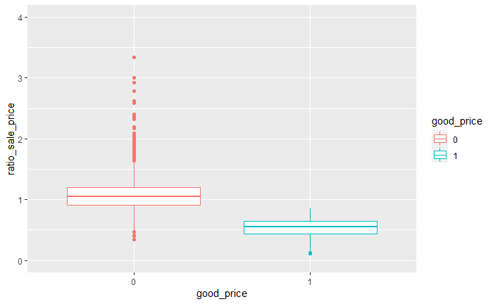

```r
# Compare good price to not good price by:
# - ratio_sale_price
# - ratio_residential_units
# - ratio_commercial_units
# - ratio_total_units
# - ratio_land_sqft
# - ratio_gross_sqft
# - ratio_year_built


### ratio_sale_price

nyc_prop_for_EDA %>%
  select(., building_class_at_tos,
         contains("sale_price"),
         good_price) %>%
  ggplot() +
  geom_boxplot(aes(x = good_price, y = ratio_sale_price, color = good_price)) +
  coord_cartesian(ylim = c(0,4))
```

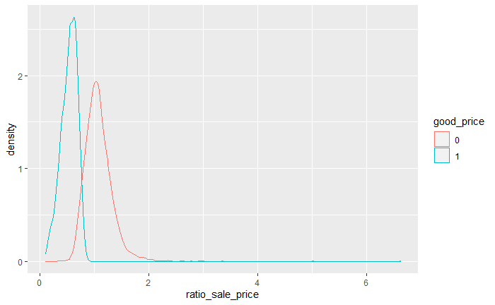

```r
nyc_prop_for_EDA %>%
  select(., building_class_at_tos,
         contains("sale_price"),
         good_price) %>%
  ggplot() +
  geom_density(aes(x = ratio_sale_price, color = good_price))
```

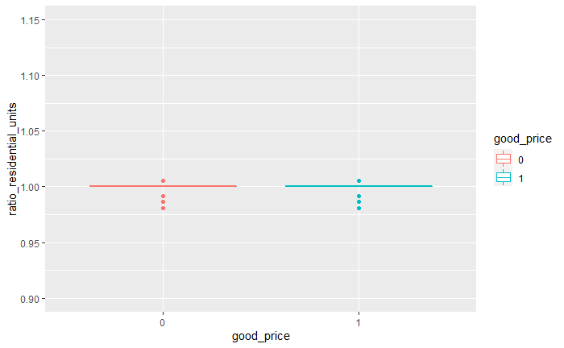

```r
### ratio_residential_units

nyc_prop_for_EDA %>%
  select(., building_class_at_tos,
         contains("residential_units"),
         good_price) %>%
  ggplot() +
  geom_boxplot(aes(x = good_price, y = ratio_residential_units, color = good_price)) +
  coord_cartesian(ylim = c(0.9, 1.15))
```

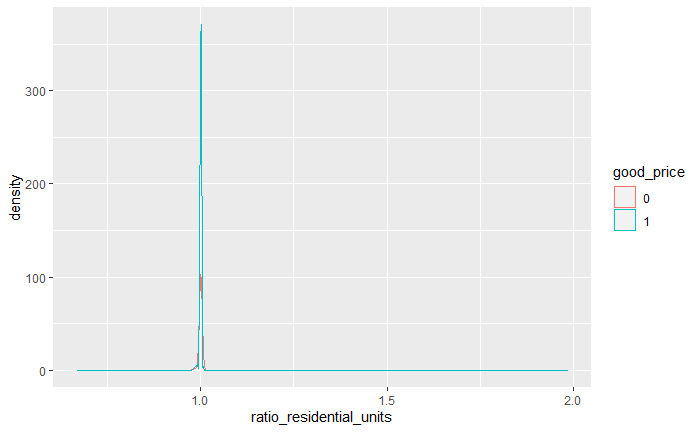

```r
nyc_prop_for_EDA %>%
  select(., building_class_at_tos,
         contains("residential_units"),
         good_price) %>%
  ggplot() +
  geom_density(aes(x = ratio_residential_units, color = good_price))
```

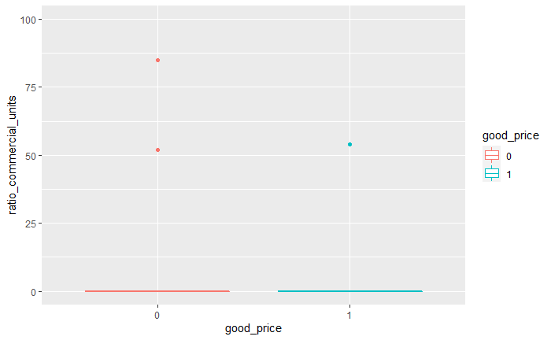

```r
###  ratio_commercial_units

nyc_prop_for_EDA %>%
  select(., building_class_at_tos,
         contains("commercial_units"),
         good_price) %>%
  ggplot() +
  geom_boxplot(aes(x = good_price, y = ratio_commercial_units, color = good_price)) +
  coord_cartesian(ylim = c(0,100))
```

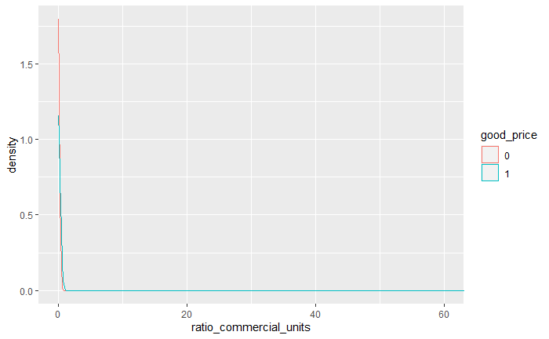

```r
nyc_prop_for_EDA %>%
  select(., building_class_at_tos,
         contains("commercial_units"),
         good_price) %>%
  ggplot() +
  geom_density(aes(x = ratio_commercial_units, color = good_price)) +
  coord_cartesian(xlim = c(0,60))
```

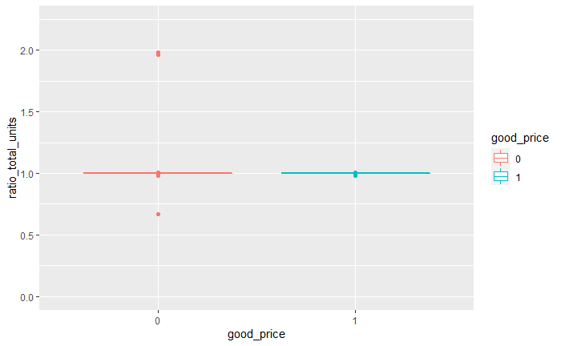

```r
### ratio_total_units

nyc_prop_for_EDA %>%
  select(., building_class_at_tos,
         contains("total_units"),
         good_price) %>%
  ggplot() +
  geom_boxplot(aes(x = good_price, y = ratio_total_units, color = good_price)) +
  coord_cartesian(ylim = c(0,2.25))
```

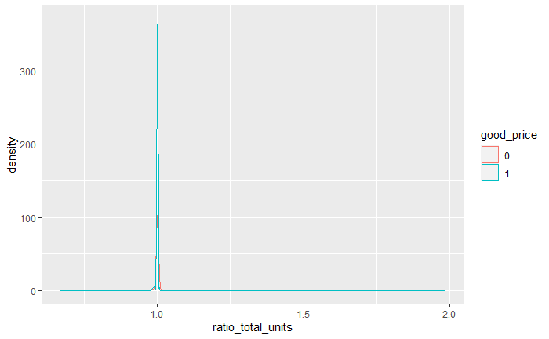

```r
nyc_prop_for_EDA %>%
  select(., building_class_at_tos,
         contains("total_units"),
         good_price) %>%
  ggplot() +
  geom_density(aes(x = ratio_total_units, color = good_price))
```